# FinalProject

Capstone Project: Loan Default Prediction

**Applied Data Science Program - MIT Professional Education**

**Phillipe Vilaça Gomes**  
Department of Computer Science of the Rey Juan Carlos University. Madrid, Spain

## Table of Content

**1. Problem Definition**  
**1.1 The Context**  
**1.2 The Objectives**  
**1.3 The Key Questions**  
**1.4 The Problem Formulation**  
**2. Exploratory Data Analysis (EDA) and Visualization**  
**2.1 Data Dictionary**  
**2.2 Data Description**  
**2.3 Univariate Analysis - Numerical Data**  
**2.4 Univariate Analysis - Categorical Data**  
**2.5 Bivariate Analysis**  
**2.6 Multivariate Analysis**  
**2.7 Key fixes**  
**2.8 Summary of Notes**  
**3. Proposed Approach**  
**3.1 Potential Techniques**  
**3.2 Overall solution design**  
**3.3 Measures of success**  
**4. Model Building**  
**4.1 Data preparation**  
**4.2 Model Evaluation Function**  
**5. Logistic Regression (Log Reg) Model**  
**5.1 Log Reg**  
**5.2 Log Reg with Balanced Precision-Recall**  
**5.3 Log Reg with Scaled Feature**  
**5.4 Log Reg with Scaled Feature and Balanced Precision-Recall**  
**5.5 Overview of Log Reg Results**  
**6. Decision Tree (DT) Model**  
**6.1 DT with Default Hyperparameters**  
**6.2 DT with Tuned Hyperparameters**  
**6.3 Overview of DT Results**  
**7. Random Forest (RF) Model**  
**7.1 RF with Default Hyperparameters**  
**7.2 RF with Tuned Hyperparameters**  
**7.3 Overview of RF Results**  
**8. Comparing Model Performances**  
**9. Conclusion and Busines Recommendations**  
**9.1 Answering the Key Questions**  
**9.2 Busines Recommendations**  
**9.3 Expected Benefits**  
**9.4 Risks and Challenges**

1. Problem Definition

1.1 The context

- This problem is related to **home loans**, one of the most crucial credit lines to increase banks' profits.
- As defaulters can reduce drastically the mentioned profit, banks often establish a process to **avoid bad loans (NPA)**.
- In this process, the bank checks **a considerable variety of attributes** and came up with a decision.
- This process requires a lot of human resources and it is considered effort-intensive, which can lead to **impaired judgment**.
- Therefore, many banks are trying to automate this process in a **free of bias and efficient way**.
- However, as these automatic procedures are based on datasets, one important thing to ensure is that **the bad behaviors in these datasets, due to errors in the human approval process, are excluded in the new and automatic procedure**.

1.2 The objectives

- Build a **classification model** to predict clients who are likely to default on their loan and give **recommendations to the bank on the important features** to consider while approving a loan.
- The classification model must be **interpretative**.
- The classification model must be **free of bias** that may be present in the dataset (due to previous bad decisions)

1.3 The Key Questions

- **Key question 1**: What drives loan default?
- **Key question 2**: What factors can be important to identify loan defaulters?
- **Key question 3**: How to model loan default as a function of other variables?
- **Key question 4**: How to use this model to automate the decisions of loan approval?
- **Key question 5**: How to cut down on losses by loan defaults?

1.4 The Problem Formulation

- Based on the data obtained via the existing loan:
  - There are **12 features** for each applicant.
  - The **target is a binary variable** indicating if the applicant has defaulted or not. (0 means loan repaid and 1 means client defaulted on loan)
- **Problem formulation**: Build a model able to predict clients likely to default on their loan (i.e; predict the *target variable Y* based on the *features X*).

2. Exploratory Data Analysis (EDA) and Visualization

**Importing libraries**

```python
# Scientific Computing
import numpy as np

# Data Analysis
import pandas as pd

# Plotting
from matplotlib import pyplot as plt
%matplotlib inline
plt.style.use('ggplot')

# Statistical Data Visualization
import seaborn as sns

# Efficient tools for machine learning and statistical modeling
from sklearn import tree

# To scale the data using z-score
from sklearn.preprocessing import StandardScaler

# To split matrices into random train and test subsets
from sklearn.model_selection import train_test_split

# Algorithms to use
from sklearn import tree
from sklearn.tree import DecisionTreeClassifier
from sklearn.ensemble import RandomForestClassifier
from sklearn.linear_model import LogisticRegression

# Metrics to evaluate the model
from sklearn import metrics
from sklearn.metrics import confusion_matrix, classification_report, recall_score, precision_score, accuracy_score, precision_recall_curve

# For tuning the model
from sklearn.model_selection import GridSearchCV

# To ignore warnings
import warnings
warnings.filterwarnings("ignore")
```

2.1 Data Dictionary

The Home Equity dataset (HMEQ) contains baseline and loan performance information for 5,960 recent home equity loans. The target (BAD) is a binary variable that indicates whether an applicant has ultimately defaulted or has been severely delinquent. This adverse outcome occurred in 1,189 cases (20 percent). 13 input variables (12 features and the target) were registered for each applicant.

- **BAD:** 1 = Client defaulted on loan, 0 = loan repaid
- **LOAN:** Amount of loan approved.
- **MORTDUE:** Amount due on the existing mortgage.
- **VALUE:** Current value of the property.
- **REASON:** Reason for the loan request. (HomeImp = home improvement, DebtCon= debt consolidation which means taking out a new loan to pay off other liabilities and consumer debts)
- **JOB:** The type of job that loan applicant has such as manager, self, etc.
- **YOJ:** Years at present job.
- **DEROG:** Number of major derogatory reports (which indicates a serious delinquency or late payments).
- **DELINQ:** Number of delinquent credit lines (a line of credit becomes delinquent when a borrower does not make the minimum required payments 30 to 60 days past the day on which the payments were due).
- **CLAGE:** Age of the oldest credit line in months.
- **NINQ:** Number of recent credit inquiries.
- **CLNO:** Number of existing credit lines.
- **DEBTINC:** Debt-to-income ratio (all your monthly debt payments divided by your gross monthly income. This number is one way lenders measure your ability to manage the monthly payments to repay the money you plan to borrow.

2.2 Data Description

**Read the dataset**

```python
hm=pd.read_csv("hmeq.csv")
```

**Copying data to another variable to avoid any changes to the original data**

```python
data=hm.copy()
```

**Displaying first and last five rows**

```python
data
```

|  | BAD | LOAN | MORTDUE | VALUE | REASON | JOB | YOJ | DEROG | DELINQ | CLAGE | NINQ | CLNO | DEBTINC |
| --- | --- | --- | --- | --- | --- | --- | --- | --- | --- | --- | --- | --- | --- |
| 0 | 1 | 1100 | 25860.0 | 39025.0 | HomeImp | Other | 10.5 | 0.0 | 0.0 | 94.366667 | 1.0 | 9.0 | NaN |
| 1 | 1 | 1300 | 70053.0 | 68400.0 | HomeImp | Other | 7.0 | 0.0 | 2.0 | 121.833333 | 0.0 | 14.0 | NaN |
| 2 | 1 | 1500 | 13500.0 | 16700.0 | HomeImp | Other | 4.0 | 0.0 | 0.0 | 149.466667 | 1.0 | 10.0 | NaN |
| 3 | 1 | 1500 | NaN | NaN | NaN | NaN | NaN | NaN | NaN | NaN | NaN | NaN | NaN |
| 4 | 0 | 1700 | 97800.0 | 112000.0 | HomeImp | Office | 3.0 | 0.0 | 0.0 | 93.333333 | 0.0 | 14.0 | NaN |
| ... | ... | ... | ... | ... | ... | ... | ... | ... | ... | ... | ... | ... | ... |
| 5955 | 0 | 88900 | 57264.0 | 90185.0 | DebtCon | Other | 16.0 | 0.0 | 0.0 | 221.808718 | 0.0 | 16.0 | 36.112347 |
| 5956 | 0 | 89000 | 54576.0 | 92937.0 | DebtCon | Other | 16.0 | 0.0 | 0.0 | 208.692070 | 0.0 | 15.0 | 35.859971 |
| 5957 | 0 | 89200 | 54045.0 | 92924.0 | DebtCon | Other | 15.0 | 0.0 | 0.0 | 212.279697 | 0.0 | 15.0 | 35.556590 |
| 5958 | 0 | 89800 | 50370.0 | 91861.0 | DebtCon | Other | 14.0 | 0.0 | 0.0 | 213.892709 | 0.0 | 16.0 | 34.340882 |
| 5959 | 0 | 89900 | 48811.0 | 88934.0 | DebtCon | Other | 15.0 | 0.0 | 0.0 | 219.601002 | 0.0 | 16.0 | 34.571519 |

5960 rows × 13 columns

**Note 1**: There are some features with missing values, it's necessary to dig deeper into this matter.

**Understanding the shape of the dataset**

```python
data.shape
```

```
(5960, 13)
```

**Note 2**: The dataset has 5960 approved loans.

**Checking the data types of the columns in the dataset**

```python
data.info()
```

```
<class 'pandas.core.frame.DataFrame'>
RangeIndex: 5960 entries, 0 to 5959
Data columns (total 13 columns):
 #   Column   Non-Null Count  Dtype
---  ------   --------------  -----
 0   BAD      5960 non-null   int64
 1   LOAN     5960 non-null   int64
 2   MORTDUE  5442 non-null   float64
 3   VALUE    5848 non-null   float64
 4   REASON   5708 non-null   object
 5   JOB      5681 non-null   object
 6   YOJ      5445 non-null   float64
 7   DEROG    5252 non-null   float64
 8   DELINQ   5380 non-null   float64
 9   CLAGE    5652 non-null   float64
 10  NINQ     5450 non-null   float64
 11  CLNO     5738 non-null   float64
 12  DEBTINC  4693 non-null   float64
dtypes: float64(9), int64(2), object(2)
memory usage: 605.4+ KB
```

**Note 3**: `REASON` and `JOB` are of object type while the rest of the columns are of numeric type.  
**Note 4**: `BAD` is a binary variable and it represents a classification. It will be the target variable.

**Dealing with missing values**

```python
data.isnull().sum()
```

```
BAD           0
LOAN          0
MORTDUE     518
VALUE       112
REASON      252
JOB         279
YOJ         515
DEROG       708
DELINQ      580
CLAGE       308
NINQ        510
CLNO        222
DEBTINC    1267
dtype: int64
```

```python
print('The percentage of missing values in the each column is: ')
print(round((100*data.isnull().sum()/len(data)),2))
```

```
The percentage of missing values in the each column is:
BAD         0.00
LOAN        0.00
MORTDUE     8.69
VALUE       1.88
REASON      4.23
JOB         4.68
YOJ         8.64
DEROG      11.88
DELINQ      9.73
CLAGE       5.17
NINQ        8.56
CLNO        3.72
DEBTINC    21.26
dtype: float64
```

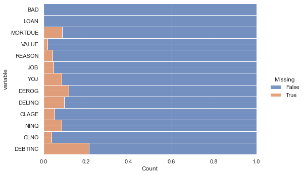

```python
sns.displot(
    data=data.isna().melt(value_name="Missing"),
    y="variable",
    hue="Missing",
    multiple="fill",
    aspect=1.5
);
```

**Note 5**: `DEBTINC` is the feature with more missing values (21.26\%), `DEROG` has 11.88\%, `NINQ`, `MORTDUE`, `YOJ` and `DELINQ` have between 8-10\% of missing values, while `VALUE`, `REASON`, `JOB`, `CLAGE` and `CLNO` have less than 5.17% of missing values.

**Converting the object type columns to categories (to reduce space)**

```python
#converting "objects" to "category" reduces the data space required to store the dataframe

cols = data.select_dtypes(['object']).columns.tolist()
#adding target variable to this list as this is an classification problem and the target variable is categorical
cols.append('BAD')

for i in cols:
    data[i] = data[i].astype('category')

data.info()
```

```
<class 'pandas.core.frame.DataFrame'>
RangeIndex: 5960 entries, 0 to 5959
Data columns (total 13 columns):
 #   Column   Non-Null Count  Dtype
---  ------   --------------  -----
 0   BAD      5960 non-null   category
 1   LOAN     5960 non-null   int64
 2   MORTDUE  5442 non-null   float64
 3   VALUE    5848 non-null   float64
 4   REASON   5708 non-null   category
 5   JOB      5681 non-null   category
 6   YOJ      5445 non-null   float64
 7   DEROG    5252 non-null   float64
 8   DELINQ   5380 non-null   float64
 9   CLAGE    5652 non-null   float64
 10  NINQ     5450 non-null   float64
 11  CLNO     5738 non-null   float64
 12  DEBTINC  4693 non-null   float64
dtypes: category(3), float64(9), int64(1)
memory usage: 483.7 KB
```

**Checking for duplicate values**

```python
data.duplicated().sum()
```

```
0
```

**Summary Statistics of the dataset for numerical variables**

```python
data.describe().T
```

|  | count | mean | std | min | 25% | 50% | 75% | max |
| --- | --- | --- | --- | --- | --- | --- | --- | --- |
| LOAN | 5960.0 | 18607.969799 | 11207.480417 | 1100.000000 | 11100.000000 | 16300.000000 | 23300.000000 | 89900.000000 |
| MORTDUE | 5442.0 | 73760.817200 | 44457.609458 | 2063.000000 | 46276.000000 | 65019.000000 | 91488.000000 | 399550.000000 |
| VALUE | 5848.0 | 101776.048741 | 57385.775334 | 8000.000000 | 66075.500000 | 89235.500000 | 119824.250000 | 855909.000000 |
| YOJ | 5445.0 | 8.922268 | 7.573982 | 0.000000 | 3.000000 | 7.000000 | 13.000000 | 41.000000 |
| DEROG | 5252.0 | 0.254570 | 0.846047 | 0.000000 | 0.000000 | 0.000000 | 0.000000 | 10.000000 |
| DELINQ | 5380.0 | 0.449442 | 1.127266 | 0.000000 | 0.000000 | 0.000000 | 0.000000 | 15.000000 |
| CLAGE | 5652.0 | 179.766275 | 85.810092 | 0.000000 | 115.116702 | 173.466667 | 231.562278 | 1168.233561 |
| NINQ | 5450.0 | 1.186055 | 1.728675 | 0.000000 | 0.000000 | 1.000000 | 2.000000 | 17.000000 |
| CLNO | 5738.0 | 21.296096 | 10.138933 | 0.000000 | 15.000000 | 20.000000 | 26.000000 | 71.000000 |
| DEBTINC | 4693.0 | 33.779915 | 8.601746 | 0.524499 | 29.140031 | 34.818262 | 39.003141 | 203.312149 |

**Note 6**: Regarding the applications:

- The average amount of **loan approved** is about 18.5k.
- Only 25% of the **approved loans** were over ~23.3k.
- The average **amount due on the existing mortgage** is about 73.7k.
- The average **current value of the property** is about 101.7k.
- Only 25% of the **property values** were over ~119.8k.
- The average **longevity at the present job** by applicants is about 9 years.
- 75% of the applicants had been **working at the same job for** at least 3 years.
- At least 75% of applications didn't present any **major derogatory report**.
- At least 75% of applications didn't present any **delinquent credit lines**.
- The average **age of the oldest credit line** is about 180 months.
- At least 25% of the applications didn't present any **recent credit inquiries**.
- 25% of the applications had more than 26 **existing credit lines**.
- The average **debt-to-income ratio** is about 33.7.
- At least 75% of the applications present a **debt-to-income ratio** inferior to 39, but there are some spikes and the maximum value is ~203.

**Summary Statistics of the dataset for categorical variables**

```python
data.describe(include=['category']).T
```

|  | count | unique | top | freq |
| --- | --- | --- | --- | --- |
| BAD | 5960 | 2 | 0 | 4771 |
| REASON | 5708 | 2 | DebtCon | 3928 |
| JOB | 5681 | 6 | Other | 2388 |

**looking at the unique values in all the categorical variables**

```python
cols_cat= data.select_dtypes(['category'])

for i in cols_cat.columns:
    print('The percentage of unique values in',i, 'are :')
    print(cols_cat[i].value_counts(normalize = True))
    print('*'*40)
```

```
The percentage of unique values in BAD are :
0    0.800503
1    0.199497
Name: BAD, dtype: float64
The percentage of unique values in REASON are :
DebtCon    0.688157
HomeImp    0.311843
Name: REASON, dtype: float64
The percentage of unique values in JOB are :
Other      0.420349
ProfExe    0.224608
Office     0.166872
Mgr        0.135011
Self       0.033973
Sales      0.019187
Name: JOB, dtype: float64
```

**Note 7**: Regarding the applications:

- **BAD** has ~80% of zeros (meaning loan repaid) and only ~20% of ones (meaning client defaulted on loan).
- The **main reason for the loan request** is DebtCon (about 69% of applications).

2.3 Univariate Analysis - Numerical Data

- In this section, convenient graphs are shown in order to get more insights into the numerical features.
- Order of analysis: LOAN, MORTDUE, VALUE, YOJ, DEROG, DELINQ, CLAGE, NINQ, CLNO, and DEBTINC.
- When the numerical feature can have a large range and it presents several observations over this range, we gonna use a boxplot and histogram in order to study their central tendency and dispersion.
- When the feature presents observations concentrated in one or more few values, we gonna use a barplot indicating the percentage of observations for each value.

```python
# Defining the hist_box() function

def hist_box(feature, data):
    f, (ax_box, ax_hist) = plt.subplots(2, sharex=True, gridspec_kw={'height_ratios': (0.15, 0.85)}, figsize=(15,10))
    sns.set(style='darkgrid')
    # Adding a graph in each part
    sns.boxplot(data[feature], ax=ax_box, showmeans=True)
    sns.distplot(data[feature], ax=ax_hist)
    ax_hist.axvline(data[feature].mean(), color='green', linestyle='--', label = 'Mean') # Green line corresponds to the mean in the plot
    ax_hist.axvline(data[feature].median(), color='orange', linestyle='-', label = 'Median') # Orange line corresponds to the median in the plot
    plt.legend()
    plt.show()
```

```python
# Function to create barplots that indicate percentage for each category/value.

def perc_on_bar(plot, feature):
    '''
    plot
    feature: categorical feature
    the function won't work if a column is passed in hue parameter
    '''

    total = len(feature) # length of the column
    for p in ax.patches:
        percentage = '{:.1f}%'.format(100 * p.get_height()/total) # percentage of each class of the category
        x = p.get_x() + p.get_width() / 2 - 0.05 # width of the plot
        y = p.get_y() + p.get_height()           # height of the plot
        ax.annotate(percentage, (x, y), size = 12) # annotate the percentage

    plt.show() # show the plot
```

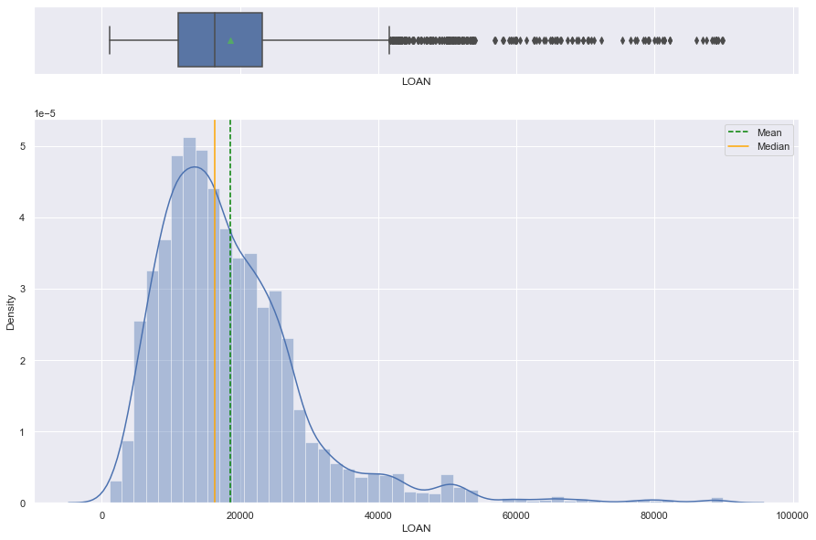

```python
hist_box('LOAN', data)
```

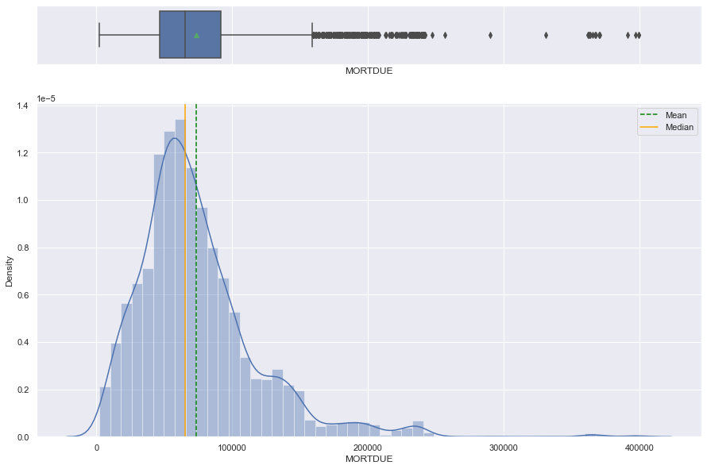

```python
hist_box('MORTDUE', data)
```

**Note 9**: `MORTDUE` has a right-skewed distribution, meaning only a few applications had high amount due on the existing mortgage.

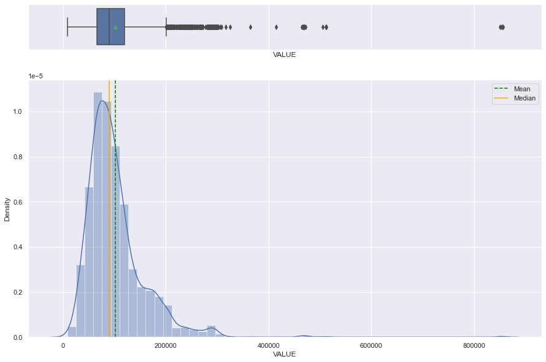

```python
hist_box('VALUE', data)
```

**Note 10**: Only a few number of applications had the current value of the property above 200k. This corroborates with **Note 6** which states that *only 25% of the property values were over ~119.8k*.

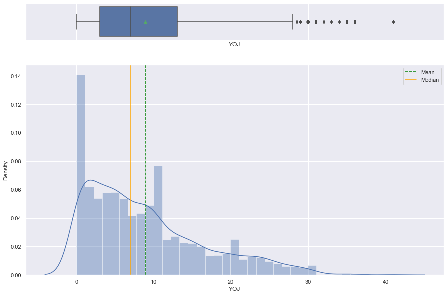

```python
hist_box('YOJ', data)
```

**Note 11**: A lot of applicants had new jobs.

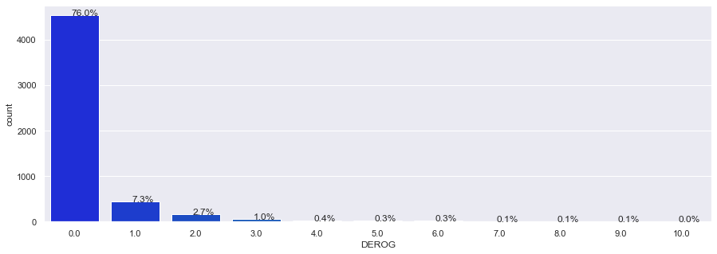

```python
#Build barplot for DEROG

plt.figure(figsize=(15,5))
ax = sns.countplot(data["DEROG"],palette='winter')
perc_on_bar(ax,data["DEROG"])
```

**Note 12**: 76% of applications didn't present any major derogatory report. This corroborates with **Note 6** which states that *at least 75% of applications didn't present any major derogatory report*.

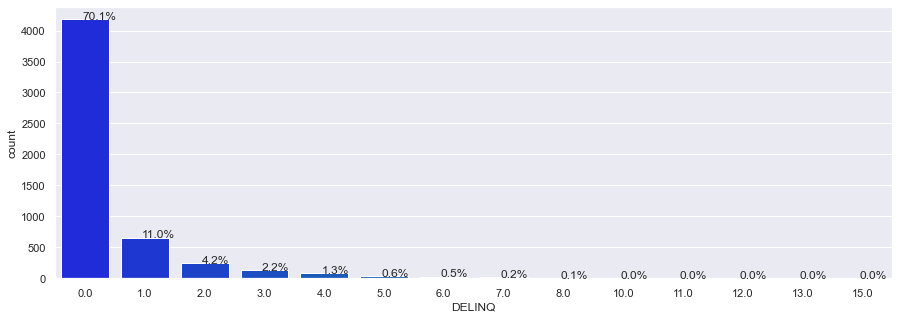

```python
#Build barplot for DEROG

plt.figure(figsize=(15,5))
ax = sns.countplot(data["DELINQ"],palette='winter')
perc_on_bar(ax,data["DELINQ"])
```

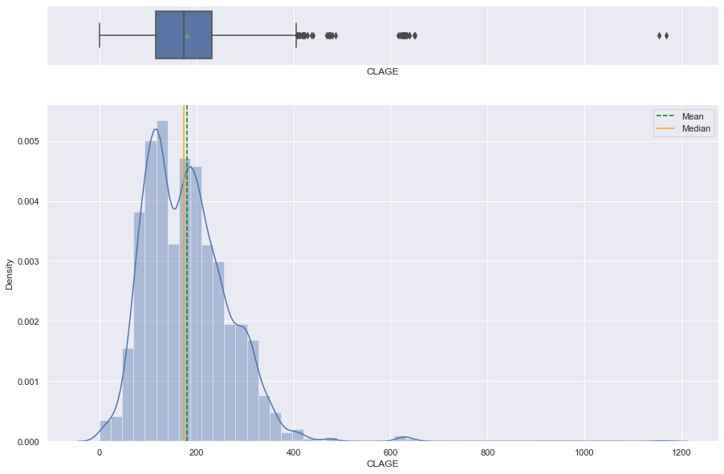

```python
hist_box('CLAGE', data)
```

**Note 14**: `CLAGE` is close to a symmetrical distribution

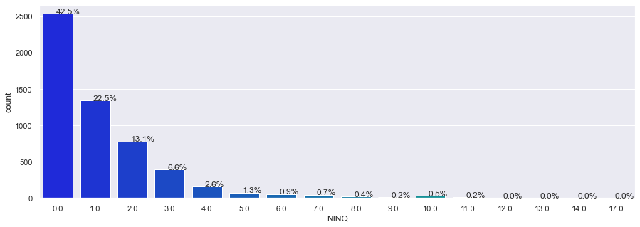

```python
#Build barplot for NINQ

plt.figure(figsize=(15,5))
ax = sns.countplot(data["NINQ"],palette='winter')
perc_on_bar(ax,data["NINQ"])
```

**Note 15**: 42.5% of the applications didn't present any recent credit inquires. This corroborates with **Note 6** which states that *at least 25% of the applications didn't present any recent credit inquires*.

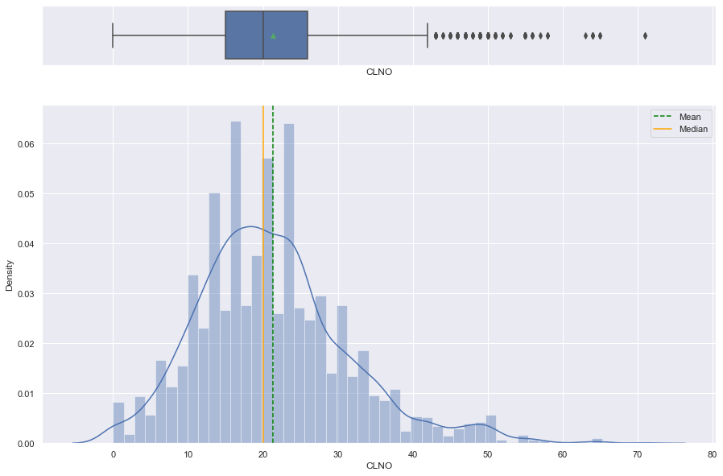

```python
hist_box('CLNO', data)
```

**Note 16**: `CLNO` is close to a symmetrical distribution.

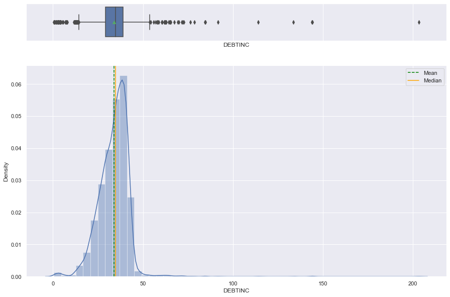

```python
hist_box('DEBTINC', data)
```

2.4 Univariate Analysis - Categorical Data

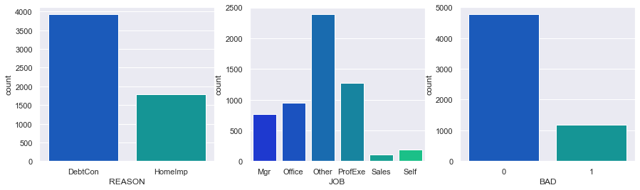

```python
plt.figure(figsize = (15, 4))
plt.subplot(131)
ax = sns.countplot(data["REASON"],palette='winter')
plt.subplot(132)
ax = sns.countplot(data["JOB"],palette='winter')
plt.subplot(133)
ax = sns.countplot(data["BAD"],palette='winter')
```

**Note 18**:

- The main reason applicants request the loan is **DebtCon**.
- The less usual job when requiring the loan is **Sales**.
- There are much more **loans repaid** than **clients defaulted on the loan**.

2.5 Bivariate Analysis

**BAD vs Continuous Variables**

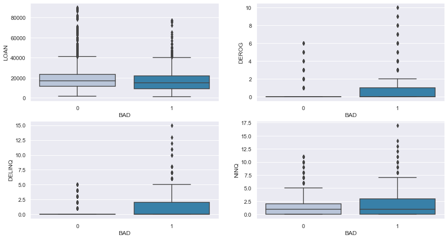

```python
plt.figure(figsize = (15, 8))
plt.subplot(221)
sns.boxplot(data["BAD"],data['LOAN'],palette="PuBu");
plt.subplot(222)
sns.boxplot(data["BAD"],data['DEROG'],palette="PuBu");
plt.subplot(223)
sns.boxplot(data["BAD"],data['DELINQ'],palette="PuBu");
plt.subplot(224)
sns.boxplot(data["BAD"],data['NINQ'],palette="PuBu");
```

**Note 19**:

**Two Continuous Variables**

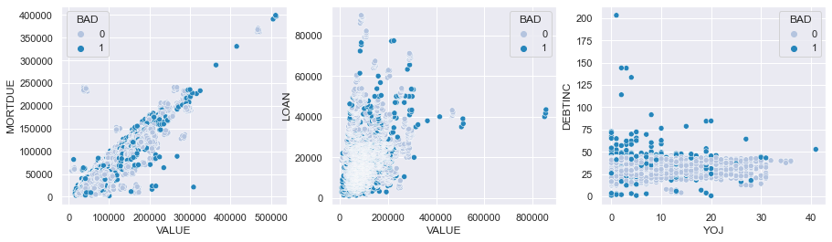

```python
plt.figure(figsize = (15, 4))
plt.subplot(131)
sns.scatterplot(data["VALUE"],data['MORTDUE'], hue=data['BAD'], palette="PuBu");
plt.subplot(132)
sns.scatterplot(data["VALUE"],data['LOAN'], hue=data['BAD'], palette="PuBu");
plt.subplot(133)
sns.scatterplot(data["YOJ"],data['DEBTINC'], hue=data['BAD'], palette="PuBu");
```

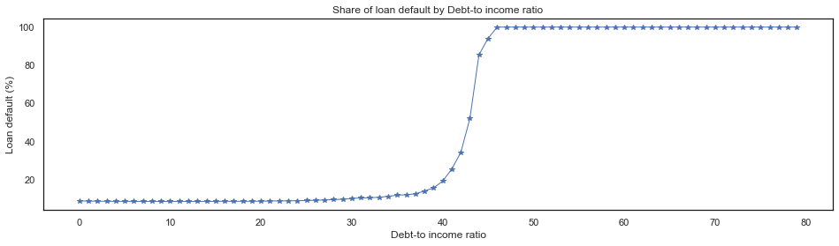

```python
perc_def = []
for i in range(80):
    perc_def.append(data[data.DEBTINC>i].BAD.value_counts(normalize = True,  sort=False)[1])

dfp = pd.Series(perc_def)
dfp = 100*dfp
fig = plt.figure(figsize=(16,4))
ax = dfp.plot(lw=1, marker='*', title='Share of loan default by Debt-to income ratio')
ax.set(xlabel='Debt-to income ratio', ylabel='Loan default (%)');
ax.set_facecolor("white");
plt.setp(ax.spines.values(), color='k')
plt.grid(True)
plt.show()
```

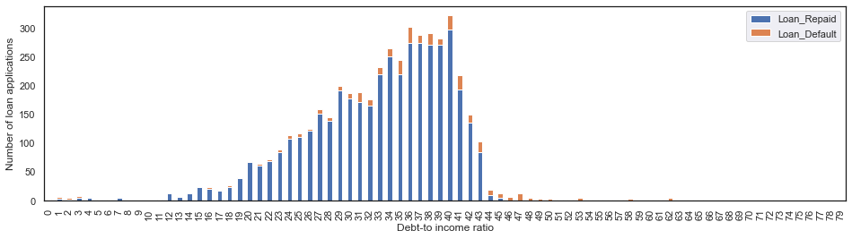

```python
bad_pay = []
god_pay = []
for i in range(80):
    god_pay.append(data[(data.DEBTINC>i)&(data.DEBTINC<i+1)].BAD.value_counts(sort=False)[0])
    bad_pay.append(data[(data.DEBTINC>i)&(data.DEBTINC<i+1)].BAD.value_counts(sort=False)[1])
dfp2 = pd.DataFrame({'Loan_Repaid': god_pay,
                   'Loan_Default': bad_pay})
ax2 = dfp2.plot.bar(stacked=True, figsize=(16,4));
ax2.set_facecolor("white");
plt.setp(ax2.spines.values(), color='k')
ax2.set(xlabel='Debt-to income ratio', ylabel='Number of loan applications');
```

**Note 20**:

- The amount due on the existing mortgage grows with the current value of the property, which is completely expected.
- Customers with a high Debt-to income ratio tend to become defaulted on loans.
  - 93% of customers with a Debt-to income ratio lower than 25 can afford the loan.
  - Roughly 50% of customers with a Debt-to income ratio higher than 43 have defaulted on the loan.
  - Customers with a Debt-to income ratio higher than 45 have always defaulted on the loan.

**BAD vs Categorical Variables**

```python
### Function to plot stacked bar charts for categorical columns

def stacked_plot(x, Y):
    # Y is the target variable
    sns.set(palette='nipy_spectral')
    tab1 = pd.crosstab(x,Y,margins=True)
    print(tab1)
    print('-'*120)
    tab = pd.crosstab(x,Y,normalize='index')
    tab.plot(kind='bar',stacked=True,figsize=(10,5))
    plt.legend(loc='lower left', frameon=False)
    plt.legend(loc="upper left", bbox_to_anchor=(1,1))
    plt.show()
```

```
BAD         0     1   All
REASON
DebtCon  3183   745  3928
HomeImp  1384   396  1780
All      4567  1141  5708
------------------------------------------------------------------------------------------------------------------------
```

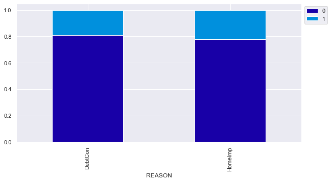

```python
# Plot stacked bar plot for BAD and REASON
stacked_plot(data['REASON'], data['BAD'])
```

**Note 21**:

```
- The reason why the loan is required does not interfere with default.
```

```
BAD         0     1   All
JOB
Mgr       588   179   767
Office    823   125   948
Other    1834   554  2388
ProfExe  1064   212  1276
Sales      71    38   109
Self      135    58   193
All      4515  1166  5681
------------------------------------------------------------------------------------------------------------------------
```

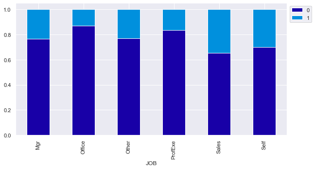

```python
# Plot stacked bar plot for BAD and REASON
stacked_plot(data['JOB'], data['BAD'])
```

```
BAD       0     1   All
DEROG
0.0    3773   754  4527
1.0     266   169   435
2.0      78    82   160
3.0      15    43    58
4.0       5    18    23
5.0       8     7    15
6.0       5    10    15
7.0       0     8     8
8.0       0     6     6
9.0       0     3     3
10.0      0     2     2
All    4150  1102  5252
------------------------------------------------------------------------------------------------------------------------
```

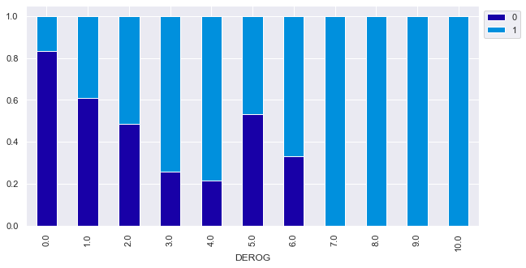

```python
# Plot stacked bar plot for BAD and DEROG
stacked_plot(data['DEROG'], data['BAD'])
```

**Note 22**:

- Applications from sales industry have a stronger impact on deliquency.
- Customer whose DEROG is more than 3 have more chances of defaulting.

2.6 Multivariate Analysis

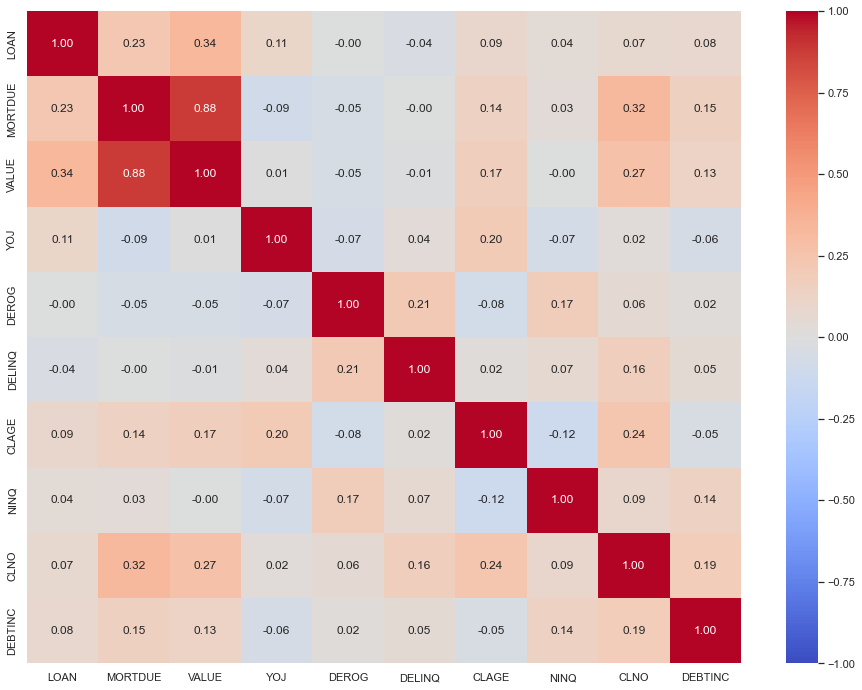

```python
# Separating numerical variables
numerical_col = data.select_dtypes(include=np.number).columns.tolist()

# Build correlation matrix for numerical columns
corr = data[numerical_col].corr()
# plot the heatmap

plt.figure(figsize=(16,12))
sns.heatmap(corr,cmap='coolwarm',vmax=1,vmin=-1, annot = True,
        fmt=".2f",
        xticklabels=corr.columns,
        yticklabels=corr.columns);
```

**Note 23**:

```
- The higher correlation is between the `MORTDUE` and `VALUE` features.
```

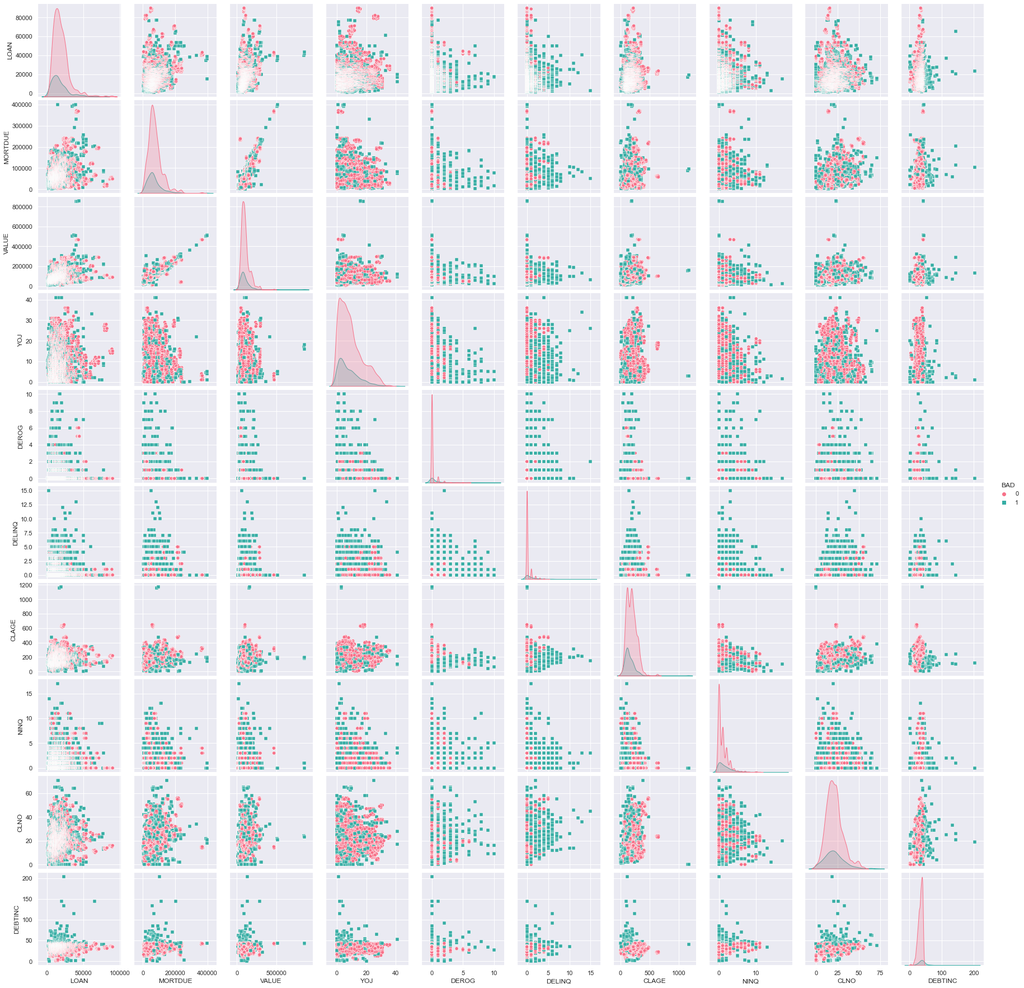

```python
sns.pairplot(data=data,hue='BAD', markers=['o', 's'], palette='husl');
```

**Note 24**:

```
- In general, reduced values of `DELINQ` and `DEROG` mean load repaid.
```

2.7 Key Fixes

**Dealing with outliers**

```python
def treat_outliers(df,col):
    '''
    treats outliers in a varaible
    col: str, name of the numerical varaible
    df: data frame
    col: name of the column
    '''

    Q1 = df[col].quantile(0.25) # 25th quantile
    Q3 = df[col].quantile(0.75)  # 75th quantile
    IQR = Q3-Q1    # IQR Range
    Lower_Whisker = Q1-1.5*IQR  # define lower whisker
    Upper_Whisker = Q3+1.5*IQR  # define upper Whisker
    df[col] = np.clip(df[col], Lower_Whisker, Upper_Whisker) # all the values smaller than Lower_Whisker will be assigned value of Lower_whisker
                                                            # and all the values above upper_whishker will be assigned value of upper_Whisker
    return df

def treat_outliers_all(df, col_list):
    '''
    treat outlier in all numerical varaibles
    col_list: list of numerical varaibles
    df: data frame
    '''
    for c in col_list:
        df = treat_outliers(df,c)

    return df
```

```python
df_raw = data.copy()
numerical_col = df_raw.select_dtypes(include=np.number).columns.tolist()# getting list of numerical columns
df = treat_outliers_all(df_raw,numerical_col)
```

**Adding new columns in the dataset for each column which has missing values**

```python
#For each column we create a binary flag for the row, if there is missing value in the row, then 1 else 0.
def add_binary_flag(df,col):
    '''
    df: It is the dataframe
    col: it is column which has missing values
    It returns a dataframe which has binary flag for missing values in column col
    '''
    new_col = str(col)
    new_col += '_missing_values_flag'
    df[new_col] = df[col].isna()
    return df
```

```python
# list of columns that has missing values in it
missing_col = [col for col in df.columns if df[col].isnull().any()]

for colmn in missing_col:
    add_binary_flag(df,colmn)
```

**Filling missing values in numerical columns with median and mode in categorical variables**

```python
#  Treat Missing values in numerical columns with median and mode in categorical variables
# Select numeric columns.
num_data = df.select_dtypes('number')

# Select string and object columns.
cat_data = df.select_dtypes('category').columns.tolist()#df.select_dtypes('object')

# Fill numeric columns with median.
df[num_data.columns] = num_data.fillna(df[num_data.columns].median())

# Fill object columns with mode.
for column in cat_data:
    mode = df[column].mode()[0]
    df[column] = df[column].fillna(mode)
```

**Checking for missing values**

```python
df.isnull().sum()
```

```
BAD                            0
LOAN                           0
MORTDUE                        0
VALUE                          0
REASON                         0
JOB                            0
YOJ                            0
DEROG                          0
DELINQ                         0
CLAGE                          0
NINQ                           0
CLNO                           0
DEBTINC                        0
MORTDUE_missing_values_flag    0
VALUE_missing_values_flag      0
REASON_missing_values_flag     0
JOB_missing_values_flag        0
YOJ_missing_values_flag        0
DEROG_missing_values_flag      0
DELINQ_missing_values_flag     0
CLAGE_missing_values_flag      0
NINQ_missing_values_flag       0
CLNO_missing_values_flag       0
DEBTINC_missing_values_flag    0
dtype: int64
```

**Saving the dataset**

```python
df.to_csv('FinalData.csv', index=False)
```

**Looking for more insights on missing data**

```
BAD                             0     1   All
DEBTINC_missing_values_flag
False                        4290   403  4693
True                          481   786  1267
All                          4771  1189  5960
------------------------------------------------------------------------------------------------------------------------
```

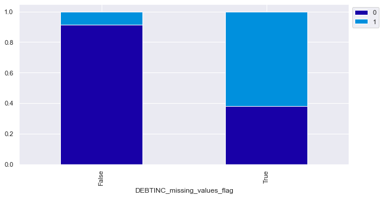

```python
stacked_plot(df['DEBTINC_missing_values_flag'], df['BAD'])
```

**Note 25**:

- ~62\% of the clients missing `DEBTINC` info defaulted in loan.
- ~9\% of the clients with `DEBTINC` info defaulted in loan.

```
BAD                           0     1   All
VALUE_missing_values_flag
False                      4764  1084  5848
True                          7   105   112
All                        4771  1189  5960
------------------------------------------------------------------------------------------------------------------------
```

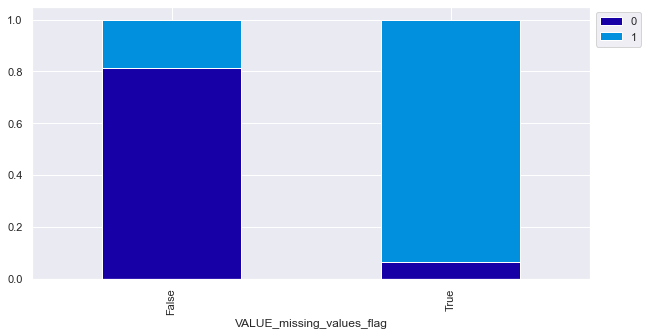

```python
stacked_plot(df['VALUE_missing_values_flag'], df['BAD'])
```

**Note 26**:

- ~94\% of the clients missing `VALUE` info defaulted in loan.
- ~19\% of the clients with `VALUE` info defaulted in loan.

2.8 Summary of Notes

**Data description**

- The dataset has 5960 rows and 13 columns.
- REASON and JOB are of object type while the rest of the columns are of numeric type.
- BAD is a binary variable and it represents a classification. It will be the target variable.
- DEBTINC is the feature with more missing values (21.26%), DEROG has 11.88%, NINQ, MORTDUE, YOJ, and DELINQ have between 8-10% of missing values, while VALUE, REASON, JOB, CLAGE, and CLNO have less than 5.17% of missing values.

**Observations**

**Data Cleaning:**

- The independent variables in this dataset have different scales. When features have different scales from each other, there is a chance that a higher weightage will be given to features that have a higher magnitude, and they will dominate over other features whose magnitude changes may be smaller but whose percentage changes may be just as significant or even larger.
- This will impact the performance of our machine learning algorithm, and we do not want our algorithm to be biased towards one feature.
- In this dataset, we have `YOJ` which is the number of **years** in the current job for applicants, and also `CLAGE` which is the age of the oldest credit line in **months**.

3. Proposed Approach

3.1 Potential Techniques

- The model will be built from predictive modeling techniques based on Decision Trees because of the following factors:
  - The model must be interpretable enough to provide a justification for any adverse behavior (rejections).
  - The model needs to be immune to bad past decisions due to human errors.
- The Decision Trees are simple to understand and interpret and mirror human decision-making more closely. Besides, they are open-box models, i.e., can visualize and understand the machine learning logic.
- The following models are highlighted to be explored:
  - **Model 1)** Logistic Regression.
  - **Model 2)** Decision Tree.
  - **Model 3)** Random Forest.
- The **Logistic Regression Model** will be tested in four versions, as follows:
  - a) No Feature Scaling.
  - b) No Feature Scaling with balanced precision-recall.
  - c) With Feature Scaling.
  - d) With Feature Scaling with balanced precision-recall.
- The **Decision Trees and Random Forest models** will be tested in two versions as follows:
  - a) Default Hiperparameters.
  - b) Tuned Hiperparameters.

3.2 Overall solution design

- In order to establish the solution design, the original dataset will be brake down into two parts: Training Set and Test Set.
  - Training set: 70% of the data.
  - Test set: 30% of the data.
- All models will be explored using only the Training Set while the Test Set will be used to access their performances.

3.3 Measures of success

**Model evaluation criterion**

**The models can make two types of wrong predictions:**

1. Predicting an applicant will default on a loan when the applicant doesn't default (False positive).
2. Predicting an applicant will not default on a loan when the applicant actually defaults (False negative).
- In the first case, the bank will lose the opportunity to increase its profits from the loan.
- In the second case, the bank will lose out on the loan.
- Therefore, the most important thing to avoid is false negatives, that is, predicting an applicant will not default on a loan when the applicant actually defaults.
- In this way, the bank would want the Recall to be maximized, the greater the Recall, the higher the chances of minimizing false negatives. Hence, the focus should be on increasing the Recall (minimizing the false negatives) or, in other words, identifying the true positives (i.e. Class 1) very well, so that the company can provide incentives to control the default rate especially.
- **Potential benefits of the candidate solutions**  
  The final solution approach will be the one with the best performance over the **Test Set** (30\% of the population) based on the maximization of the **Recall**. In this way, the automatization of the process may allow a significant reduction in the loan default. Besides, it will also allow a better understanding of the important features to consider while approving a loan.

4. Model Building

4.1 Data Preparation

**Separating the target variable from other variables**

```python
df = pd.read_csv('FinalData.csv')
```

```python
# Drop the dependent variable from the dataframe and create the X(independent variable) matrix
X = df.drop(columns = ['BAD'])

# Create dummy variables for the categorical variables - Hint: use the get_dummies() function
# Remove _________ and complete the code
to_get_dummies_for = X.select_dtypes(['object', 'bool']).columns.tolist()
X = pd.get_dummies(data = X, columns = to_get_dummies_for, drop_first = True)

# Create y(dependent varibale)
y = df.BAD
```

**Scaling the data**

The independent variables in this dataset have different scales. When features have different scales from each other, there is a chance that a higher weightage will be given to features that have a higher magnitude, and they will dominate over other features whose magnitude changes may be smaller but whose percentage changes may be just as significant or even larger. This will impact the performance of our machine learning algorithm, and we do not want our algorithm to be biased towards one feature.

The solution to this issue is **Feature Scaling**, i.e. scaling the dataset so as to give every transformed variable a comparable scale.

In this problem, we will use the **Standard Scaler** method, which centers and scales the dataset using the Z-Score.

It standardizes features by subtracting the mean and scaling it to have unit variance.

The standard score of sample x is calculated as:

**z = (x - u) / s**

where **u** is the mean of the training samples (zero) and **s** is the standard deviation of the training samples.

```python
# Scaling the data
sc = StandardScaler()

X_scaled = sc.fit_transform(X)

X_scaled = pd.DataFrame(X_scaled, columns = X.columns)
```

**Note 27**:

- `CLAGE` is a feature scaled **in months**, while `YOJ` is scaled in **years**.
- Decision trees and ensemble methods do not require feature scaling to be performed as they are not sensitive to the the variance in the data.

**Splitting the data into 70% train and 30% test set**  
Some classification problems can exhibit a large imbalance in the distribution of the target classes: for instance, there could be several times more negative samples than positive samples. In such cases, it is recommended to use the **stratified sampling** technique to ensure that relative class frequencies are approximately preserved in each train and validation fold.

**Scaled Feature**

```python
# Split the data into training and test set - Scaled X
x_train_S, x_test_S, y_train_S, y_test_S = train_test_split(X_scaled, y, test_size = 0.3, random_state = 1, stratify = y)
```

**Non Scaled Feature**

```python
# Split the data into training and test set - X
x_train, x_test, y_train, y_test = train_test_split(X, y, test_size = 0.3, random_state = 1, stratify = y)
```

4.2 Model Evaluation Function

```python
#creating metric function
def metrics_score(actual, predicted):
    print(classification_report(actual, predicted))
    cm = confusion_matrix(actual, predicted)
    plt.figure(figsize=(8,5))
    sns.heatmap(cm, annot=True,  fmt='.2f', xticklabels=['Eligible', 'Not Eligible'], yticklabels=['Eligible', 'Not Eligible'])
    plt.ylabel('Actual')
    plt.xlabel('Predicted')
    plt.show()
```

5. Logistic Regression Model

- Logistic Regression is a supervised learning algorithm, generally used for **binary classification problems**, i.e., where the dependent variable is categorical and has only two possible values. In logistic regression, we use the sigmoid function to calculate the probability of an event Y, given some features X as:

  ```
                                      P(Y)=1/(1 + exp(-X))
  ```

**Defining the Logistic regression model**

```python
lg = LogisticRegression()
```

5.1 Log Reg

**Fitting the model on the training data**

```python
lg.fit(x_train,y_train)
```

```
LogisticRegression()
```

**Checking the performance on the train dataset**

```
              precision    recall  f1-score   support

           0       0.80      1.00      0.89      3340
           1       0.00      0.00      0.00       832

    accuracy                           0.80      4172
   macro avg       0.40      0.50      0.44      4172
weighted avg       0.64      0.80      0.71      4172
```

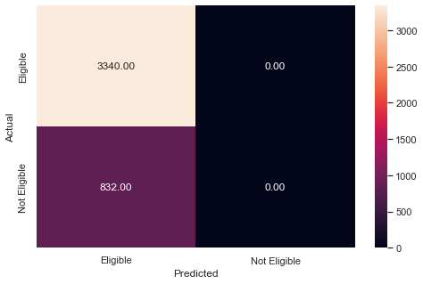

```python
y_pred_train = lg.predict(x_train)
metrics_score(y_train, y_pred_train)
```

**Checking the performance on the test dataset**

```
              precision    recall  f1-score   support

           0       0.80      1.00      0.89      1431
           1       0.00      0.00      0.00       357

    accuracy                           0.80      1788
   macro avg       0.40      0.50      0.44      1788
weighted avg       0.64      0.80      0.71      1788
```

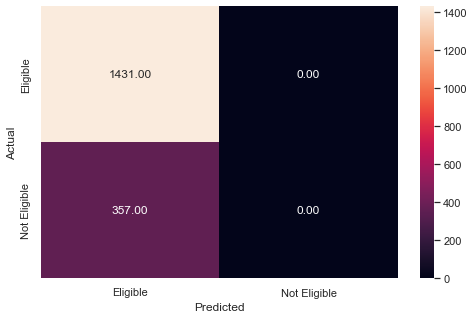

```python
y_pred_test = lg.predict(x_test)
metrics_score(y_test, y_pred_test)
```

**Checking the importance of features**

```python
# The coefficients of the logistic regression model give us the log of odds, which is hard to interpret in the real world.
# We can convert the log of odds into odds by taking its exponential.
odds = np.exp(lg.coef_[0]) # Finding the odds

# Adding the odds to a DataFrame and sorting the values
pd.DataFrame(odds, x_train.columns, columns = ['odds']).sort_values(by = 'odds', ascending = False)
```

|  | odds |
| --- | --- |
| DEBTINC_missing_values_flag_True | 1.000065 |
| NINQ | 1.000056 |
| VALUE_missing_values_flag_True | 1.000010 |
| JOB_Self | 1.000004 |
| JOB_Sales | 1.000002 |
| VALUE | 1.000001 |
| CLAGE_missing_values_flag_True | 1.000000 |
| DEROG | 1.000000 |
| DELINQ | 1.000000 |
| CLNO_missing_values_flag_True | 0.999999 |
| REASON_missing_values_flag_True | 0.999999 |
| REASON_HomeImp | 0.999998 |
| MORTDUE_missing_values_flag_True | 0.999998 |
| MORTDUE | 0.999997 |
| JOB_ProfExe | 0.999995 |
| JOB_missing_values_flag_True | 0.999994 |
| NINQ_missing_values_flag_True | 0.999994 |
| YOJ_missing_values_flag_True | 0.999993 |
| DELINQ_missing_values_flag_True | 0.999992 |
| JOB_Other | 0.999992 |
| JOB_Office | 0.999991 |
| DEROG_missing_values_flag_True | 0.999990 |
| LOAN | 0.999982 |
| DEBTINC | 0.999954 |
| CLNO | 0.999873 |
| YOJ | 0.999779 |
| CLAGE | 0.994409 |

**Note 28**: Performance of logistic regression (No Feature Scaling)

- This model had the same performance on both the train and test dataset:
  - Accuracy of 80%.
  - The recall is 100% for class 0 and 0% for class 1.
  - The model is good at identifying the eligible customers, but it doesn't identify any non-eligible customers.
  - As the model had identified all customers as eligible customers, all the features have roughly the same impact.

5.2 Log Reg with Balanced Precision-Recall

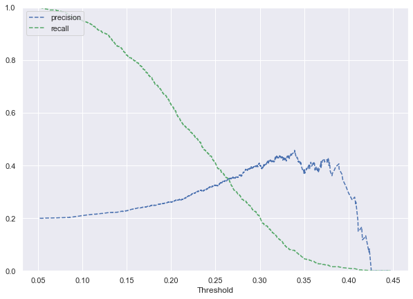

```python
# The Precision-Recall Curve for Logistic Regression


y_scores_lg = lg.predict_proba(x_train) # predict_proba gives the probability of each observation belonging to each class


precisions_lg, recalls_lg, thresholds_lg = precision_recall_curve(y_train, y_scores_lg[:, 1])

# Plot values of precisions, recalls, and thresholds
plt.figure(figsize = (10, 7))

plt.plot(thresholds_lg, precisions_lg[:-1], 'b--', label = 'precision')

plt.plot(thresholds_lg, recalls_lg[:-1], 'g--', label = 'recall')

plt.xlabel('Threshold')

plt.legend(loc = 'upper left')

plt.ylim([0, 1])

plt.show()
```

**Note 29**: The precision and the recall are balanced for a threshold of about 0.26.

```
              precision    recall  f1-score   support

           0       0.84      0.82      0.83      3340
           1       0.34      0.36      0.35       832

    accuracy                           0.73      4172
   macro avg       0.59      0.59      0.59      4172
weighted avg       0.74      0.73      0.74      4172
```

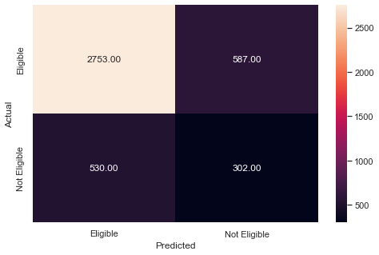

```python
optimal_threshold1 = .26

y_pred_proba_train = lg.predict_proba(x_train)

metrics_score(y_train, y_pred_proba_train[:, 1] > optimal_threshold1)
```

```
              precision    recall  f1-score   support

           0       0.84      0.82      0.83      1431
           1       0.34      0.38      0.36       357

    accuracy                           0.73      1788
   macro avg       0.59      0.60      0.59      1788
weighted avg       0.74      0.73      0.74      1788
```

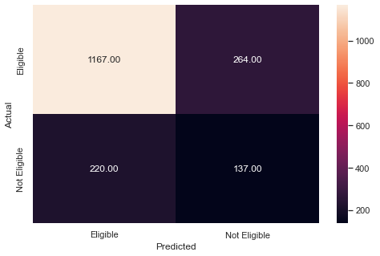

```python
optimal_threshold1 = .26

y_pred_proba_test = lg.predict_proba(x_test)

metrics_score(y_test, y_pred_proba_test[:, 1] > optimal_threshold1)
```

**Note 30**: Performance of logistic regression (No Feature Scaling with balanced precision-recall):

- Train dataset:
  - Accuracy of 73%.
  - The recall is 82% for class 0 and 36% for class 1.
- Test dataset:
  - Accuracy of 73%.
  - The recall is 82% for class 0 and 38% for class 1.

5.3 Log Reg with Scaled Feature